# RPS Bot Analysis

## Introduction

We investigate people’s performance in the rock, paper, scissors game (RPS) against a series of bots employing increasingly complex strategies.

What patterns do people detect when playing against bots that have a stable dependency structure? Is people’s ability to win consistently against a bot predicted by the complexity of the bot’s strategy?

We find that people show a reliable ability to exploit simple patterns based on their own or the bot’s previous moves, but fail to comprehensively exploit more complex dependency structures that are conditioned on both previous moves and their accompanying outcomes, despite the fact that people’s own move choices exhibit these dependencies when playing against other humans (Experiment 1).

## Methods

A total of 217 participants played matches consisting of 300 rounds of RPS. Each participant was paired up against one of 7 stable bot strategies for the duration of the match.

The number of participants that played complete matches against each bot strategy is shown below.

| Strategy | N |
| --- | --- |
| Previous move (+) | 32 |
| Previous move (-) | 30 |
| Opponent previous move (+) | 31 |
| Opponent previous move (0) | 32 |
| Win-stay-lose-positive | 30 |
| Win-positive-lose-negative | 31 |
| Outcome-transition dual dependency | 31 |

In detail, the strategies in the table above are as follows:

- **Previous move (+)**: The bot has a 90% chance of making a *positive transition (+)* from its own previous move (i.e., rock -> paper, paper -> scissors, scissors -> rock). In other words, the bot usually transitions to the move that will beat what it just played (here and in all other strategies, the remaining 10% is distributed evenly across the other two transitions).
- **Previous move (-)**: The bot has a 90% chance of making a *negative transition (-)* from its own previous move (i.e., rock -> scissors, scissors -> paper, paper -> rock). In other words, the bot usually transitions to the move that will *lose* to what it just played.
- **Opponent previous move (+)**: The bot has a 90% chance of making a *positive transition* from its *opponent’s* previous move. In other words, the bot usually transitions to the move that will beat what its opponent just played.
- **Opponent previous move (0)**: The bot has a 90% chance of making a *null transition (0)* from its *opponent’s* previous move. In other words, the bot usually copies what its opponent just played.
- **Win-stay-lose-positive**: The bot has a 90% chance of making a null transition after each win, a positive transition after each loss, and a negative transition after each tie.
- **Win-positive-lose-negative**: The bot has a 90% chance of making a positive transition after each win, a negative transition after each loss, and a null transition after each tie.
- **Outcome-transition dual dependency**: The bot has a 90% chance of making a particular transition (+, -, 0) for every combination of previous outcome *and* previous transition. For example, if the bot has just won from a positive transition, it might have a 90% chance of making a negative transition, but if it just won from a negative transition, it might instead have a 90% chance of a positive transition.

The names for each strategy above are used throughout the remainder of the analyses.

## Results

### Distribution of win count differentials

How well do participants fare against each bot strategy? Shown below is the distribution of participant win count differentials against each bot strategy, with summary statistics labeled for the distribution.

The expected performance if participants were playing at chance levels is shown in the final plot for comparison: it approximates a Gaussian centered at 0.

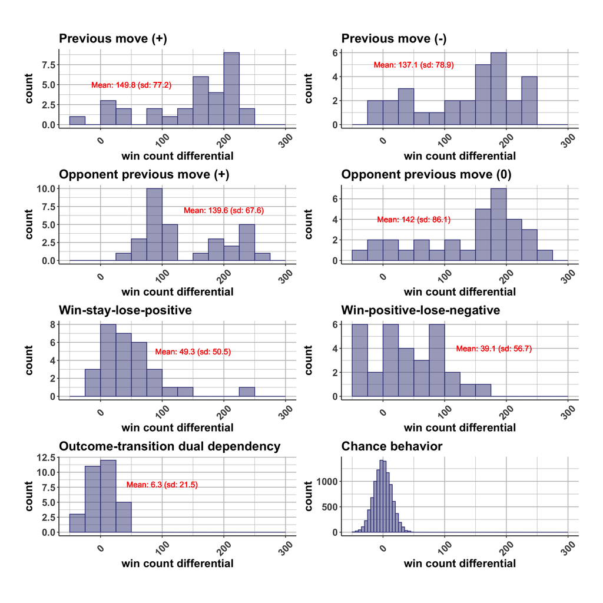

### Summary of win count differentials

The distributions above are summarized in the figure below, which shows mean and SEM of empirical win count differentials against each bot strategy. The red line indicates chance performance.

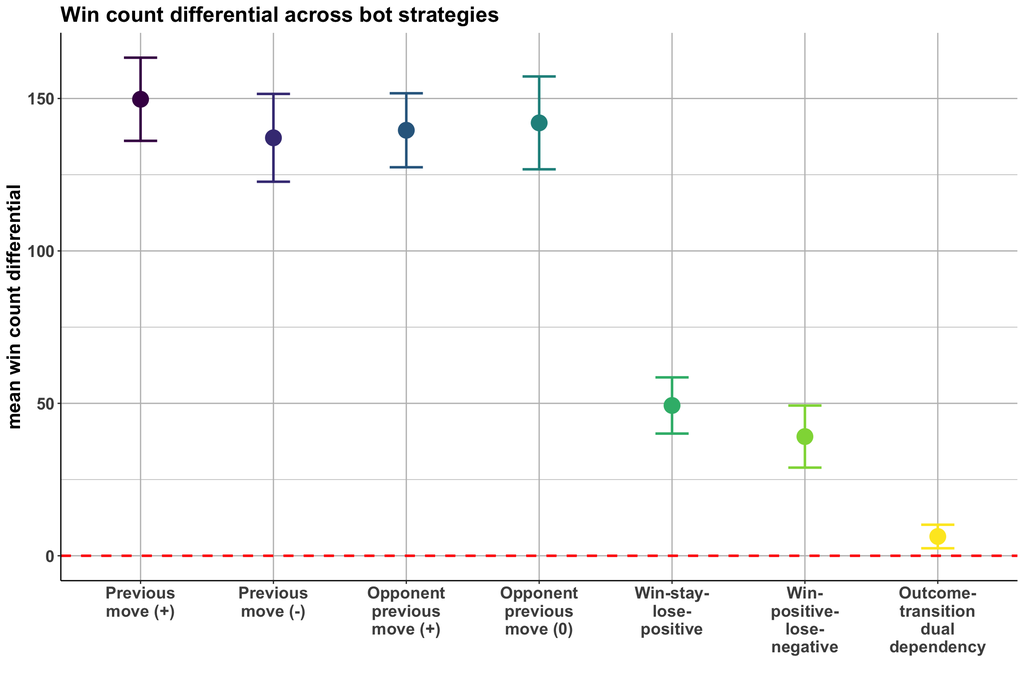

### Learning rate against each bot strategy

The above results suggest that participants were able to capitalize early on against the strategies where we see higher win count differentials, but may have struggled to figure out outcome-dependent strategies such as win-stay-lose-positive.

Below, we plot the average of participant win percentages in bins of N rounds over the course of the match (shown below with 30 rounds per bin). The red line indicates chance performance.

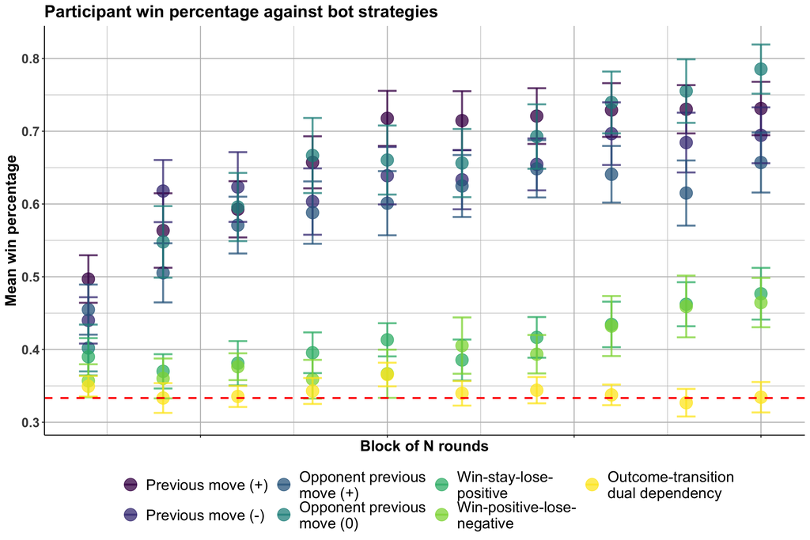

Consistent with the overall win count differentials, we see that for the bot strategies that participants achieved a high win count differential against, participants perform well above chance from early on. Meanwhile, for the outcome-dependent strategies (win-stay-lose-positive and win-positive-lose-negative), participants only seem to figure out what the bot is doing in the final third or so of the match. Finally, for the outcome-transition dual dependency strategy, participants never perform above chance levels.

### What do people learn about each bot?

The win percentage data by bin above suggests that people have mostly figured out the dependency structure for the simpler bots from the beginning, but may not fully figure out the outcome-dependent bot strategies: their progress at the end may reflect figuring out single pieces of the bot’s dependency structure.

To investigate this, below we plot overall participant win percentages against each bot strategy, based on the relevant conditioning outcome for that bot strategy. In the first two rows, we show win percentages against the previous move strategies based on bot previous moves and player previous moves, respectively. In the next two rows, we show win percentages against the previous outcome strategies (win, tie, loss) based on the bot’s previous outcome, *as well as the outcome two rounds back* for the bot. Though the bot’s strategy is only dependent on its previous outcome, people’s win count percentages suggest that they fall into patterns of strong dependency on the outcome two rounds ago.

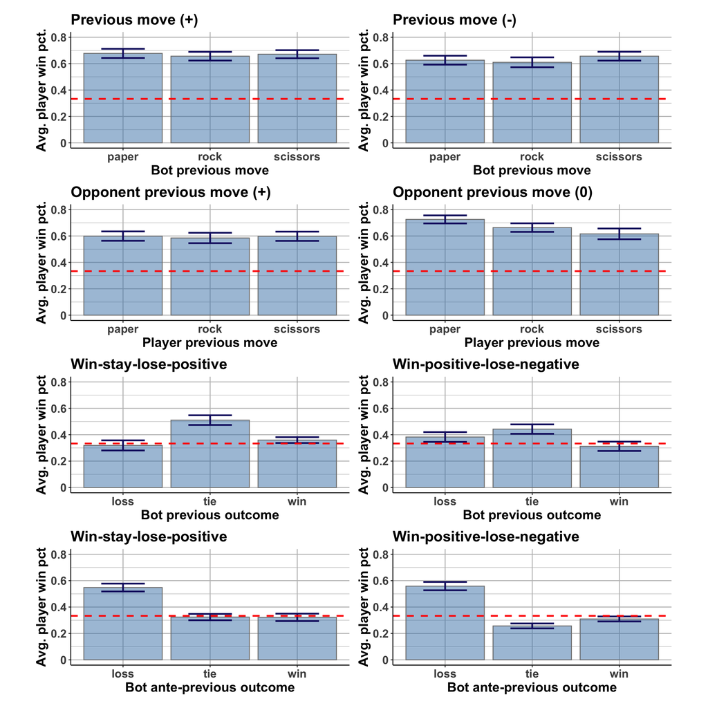

It’s clear that while people have mostly figured out the full dependency for the simpler bots, they may only figure out single aspects of the outcome-dependent bot strategies. Most interestingly of all, people show a modest ability to win against the bot when the previous round was a tie, but a very strong win percentage when the outcome *two rounds ago* was a loss for the bot. This seems to reflect unique adaptations to multi-round patterns in bot behavior that are contingent on transitions and outcomes.

## Appendix: Slider Data

Below we show Likert scale slider responses for the five questions participants were shown after completing the RPS game. There are no major differences across bot strategies for any of the questions provided.

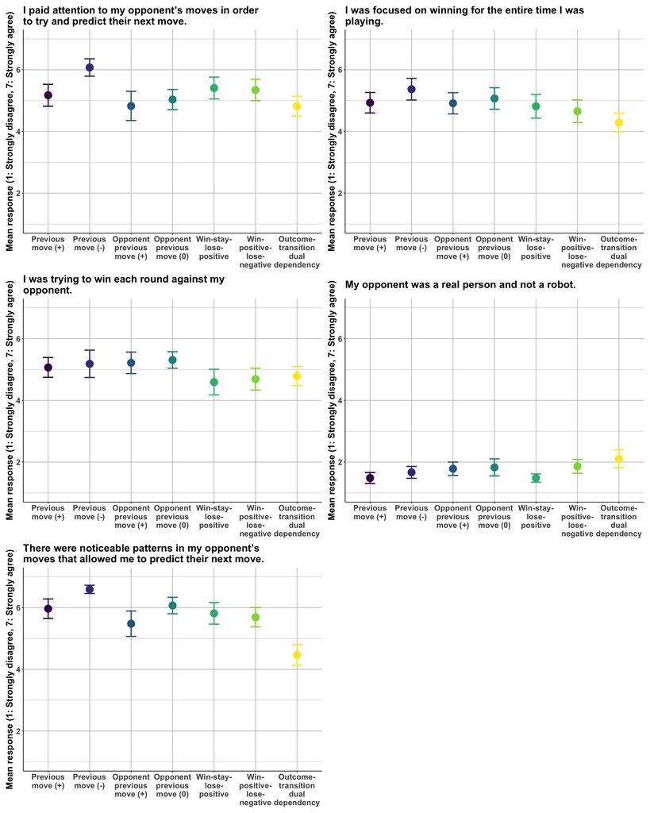

## Appendix: Free Response Data

Below is a table of free response answers, by bot strategy. Participants were prompted with the following: *“In the text box below, please describe any strategies you used to try and beat your opponent.”*

| Strategy | Game ID | Player ID | Free Response |
| --- | --- | --- | --- |
| Previous move (+) | 0c80e26b-f4bf-4d1e-8edc-93cfe57606c8 | d374e93f-df3b-4adc-a4da-aaf933d895c9 | I tried to go as fast as possible to confuse my opponent |
| Previous move (+) | 0e42c8ed-dec4-45f1-bd15-4de1a28ba05c | 8766a7e1-c137-41aa-a9ed-8b7f18a3bc16 | At first I was just pressing rock, because rock has pretty good chances, but after realizing the pattern in the choice of my opponent I was able to figure out which object he was going to chose before… |
| Previous move (+) | 27d2ce58-ed12-4d9c-b298-379598c5e69b | 20d0d9b2-261a-490a-a3d0-d61621fbe9dd | At first I thought it was completely random until i found out that once I won something for example I played ROCK and they played SCISSORS, I saw it kept going down the line ROCK>PAPER>SCISSORS. But s… |
| Previous move (+) | 3ae4c30e-160f-406c-b1ab-b2e746852e40 | f557e4ca-448e-4d94-bc10-fe00e4f9e887 | The opponents choices were predictable. For that reason if I chose rock In the previous round then my next guess would be to pick paper. Once I chose paper my next guess would be scissors. I would go … |
| Previous move (+) | 44589a27-44d6-4a44-8f45-0291cd0e59ee | e75c7306-0f6c-4fd8-8756-e41f42f1e912 | Observe their pattern |
| Previous move (+) | 4f83446c-8546-4427-9814-9fb33449a802 | 386e418a-8a16-45d5-acf7-3b85a2999814 | I found a pattern after the first 10-20 rounds and realized that my opponent was going from rock to paper to scissors consistently, but then only occasionally switching up the pattern to something els… |
| Previous move (+) | 549f73f4-7a68-4d78-abb4-76d6dbb9e8f2 | 7c2e9a45-3e56-4a41-96e5-b59868f2e5cb | I noticed that there was a general pattern of the computer going rock, paper, scissors and then repeating that pattern so I simply followed the pattern necessary to beat it. Occasionally the computer … |
| Previous move (+) | 5855b4e8-b726-4704-a08b-d411114f0487 | b4a54509-2b90-4e9d-b3cd-b4ff11563835 | Initially, I used a strategy of choosing the option that my opponent had previously chosen. This strategy has proven useful in the game if I play it with people in real life. However, my opponent in t… |
| Previous move (+) | 6f0aa4e2-1f8f-478e-b175-8fd752c8cec8 | 6c6c787a-5e80-4818-98f0-c0d1c0cb33c5 | If opponent picks rock, their next pick will likely be what beats rock, which is paper. So I will pick scissors. The opponent will likely pick what will beat the thing they lost with before. |
| Previous move (+) | 7a9914e9-75c5-43e3-8e52-e995fdaea545 | 33125e3d-2faf-4de5-99b0-d63a196d5deb | i noticed that the winning action cycled in order through all three from left to right |
| Previous move (+) | 7b0a80fe-0c9e-442f-8bcb-c204352fda24 | 0be13e74-9bbe-488d-af6d-36eabd5997be | the opponent was on a loop, so i just stayed one ahead and paid attention to when the loop changed |
| Previous move (+) | 86ce3ea0-6e6e-4bc3-bc8d-6b4a60c455b4 | 1c4eedbb-5be3-48b2-a3c0-a5b8518ebb9f | I tried to find a pattern in my opponent’s choices. Then used that to decide how to win. |
| Previous move (+) | 890987cf-83e9-429f-a435-abab474695bf | fb56004d-b76b-430c-8ad4-7fa38309d854 | Strategies I tried we picking the same thing multiple times in a row. |
| Previous move (+) | 8a2fffb9-4df6-4f62-aaa4-8e20bdb59847 | 2ab713fa-cfe7-4993-a8d0-19c7770e6f91 | At first, I was analyzing my opponent’s movement to try to predict what he will choose after. Later on, I realize the pattern in which the icons where selected |
| Previous move (+) | 8bc3f874-d5db-45b6-9eca-17b559b3a398 | c1b3a29d-fdd6-4c3d-b533-47ba39fdd171 | The opponent went in a set pattern, so I chose the move that beat that pattern, and adjusted accordingly whenever there was a tie. |
| Previous move (+) | 8bd63781-8774-4221-a739-8a1e05af5107 | bcfa93ab-0b78-4483-b54d-06271453f61e | I didn’t use any. |
| Previous move (+) | 9046726f-5ac3-4c2c-afca-9a0f6e1d2fd1 | d256f026-6da6-46b0-8f2e-984856a75c95 | I clicked rock, paper, and then scissors. If I won, I would choose the next in order, if I lost or tied, I would choose it until I won [newline] |
| Previous move (+) | 91fc38d6-3e79-49b3-999c-e073c3555947 | 118b68fa-b15b-4e94-9404-f41a54fa7c33 | At first I kep playing moves that I wanted to do, but then I noticed that this was not working. I had to gain a strategy so I decided to alternate from all of the choices. Then I kept losing so then I… |
| Previous move (+) | 9239be27-574b-468e-8597-7bac064e9ce5 | 0f018a63-f1eb-421e-8cef-9b5e021d1221 | There seemed to be a sequence with the opponent so i tried to follow that |
| Previous move (+) | a1086b75-b314-41f5-8000-e7677c52e6e8 | 76f7fa2e-8f2a-49f8-b876-777910328350 | In the beginning, I did not have a strategy at all. After a while, I recognized a pattern that my opponent always chose the following object while occasionally doing the same object twice. If they did… |
| Previous move (+) | afdc17b5-4bcc-46d2-b751-c1420febb9ff | f5c831c1-ec42-40e2-b2c2-8f5b8046bf98 | Will always go to the right after doing a change and back to a pattern. |
| Previous move (+) | bd0681c1-5013-4132-b540-3098df50b662 | 35893075-e4cf-411f-bf9a-ecf2a813db81 | ok so i eventually figured out it goes in loop from left to right over and over but then it’ll randomly re-start in a new place |
| Previous move (+) | bdae4b90-5c3e-4f71-86b4-a1f6f652b797 | f3540a99-31be-4868-aa91-39801ac216ba | It was clear after a few rounds that the opponent was simply cycling through each option in order. So I just did the same, but one step ahead. The cycle is disrupted every few rounds but it re-calibra… |
| Previous move (+) | bead7b05-0d45-43da-8fb9-9cc2981be09f | 79a2d092-4475-435d-972c-e9036a3de75d | I saw a rotating pattern |
| Previous move (+) | c9fbe4e5-af61-47b1-a364-924cdde91d26 | 489e572a-1c73-4de5-bed2-9733b137b31d | Strategies included knowing what the opponent played and how often it repeated. The opponent used rock, paper, scissors once before repeating the same three cards. Given this information, if I lose th… |
| Previous move (+) | d1e03620-24d6-4fac-9e26-adb78b32b965 | 02c20c10-8e89-4339-b14a-3daea29b5752 | I followed their patterns. When they changed their pattern, I tried to figure out what it was. |
| Previous move (+) | d423a64a-419a-4377-925f-a2e7b13dfa2e | 549e1b25-192c-4d12-bd12-e5a7f6ca8807 | Typically the “opponent” followed a pattern of going through each of the options and only occasionally switched it. After the switch though it went back to the same pattern. |
| Previous move (+) | d4b32ec9-1250-4ffb-b581-6d060d9d6074 | 0d3cdb21-e4cc-4822-9627-d1d02b9cb2f1 | First I simply tried playing the game by guessing which turn it would make. Than I realized the game had a pattern to it and I simply just followed the pattern after that to get to my goal. The patter… |
| Previous move (+) | e7477167-f461-4480-b357-eaece9044dd8 | fe8153e9-03d0-4cbd-b162-4951af4aff11 | I noticed that at some points there would be a long period where the opponent would repeatedly use rock, paper, scissors in that order. Since I could predict which move the opponent would play, it was… |
| Previous move (+) | ec8c35e1-ed92-42be-92a4-1d73e662b9a0 | 58aaeb60-714f-46d2-81e8-c44d0a7b2792 | I don’t disclose my strategies |

[output cut: 186 more lines]